# 021_Embellishing the Map

### 2.2.3 Embellishing the map

You have now drawn your first maps in R showing the *roads*, *breaches of peace* and *census blocks* in **New Haven**. However, maps generally need more information than what was plotten in the previous page. In particular, someone who had no prior knowledge of **New Haven** may not realise the geographicla extent (in miles or kilometres) of the area. Assuming you kept the map window from the previous section, you can still add a scale using `map.scale` command. This command has a large number of parameters. Enter:

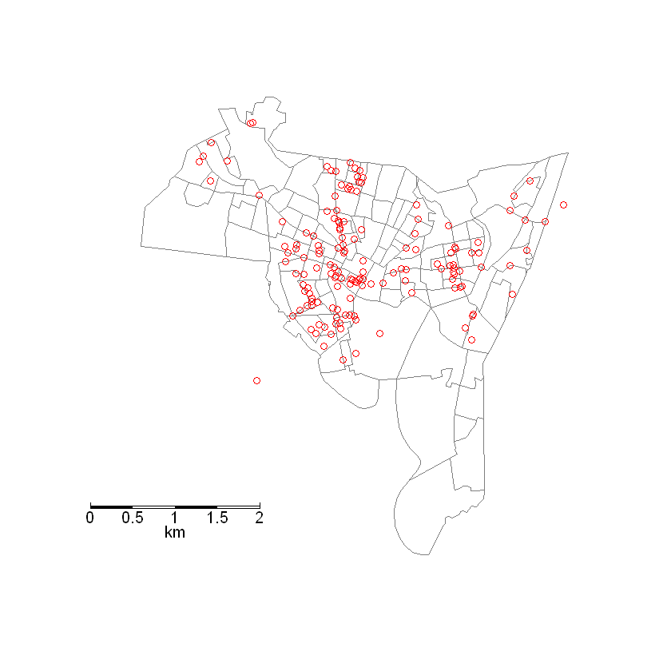

```r
plot(blocks, lwd = 0.5, border = "grey50")
plot(breach, col = "red", pch = 1, add = TRUE)
map.scale(534750, 152000, 15000, "km", 4, 0.5)
```

A second embellishment is a north arrow. To add this, enter:

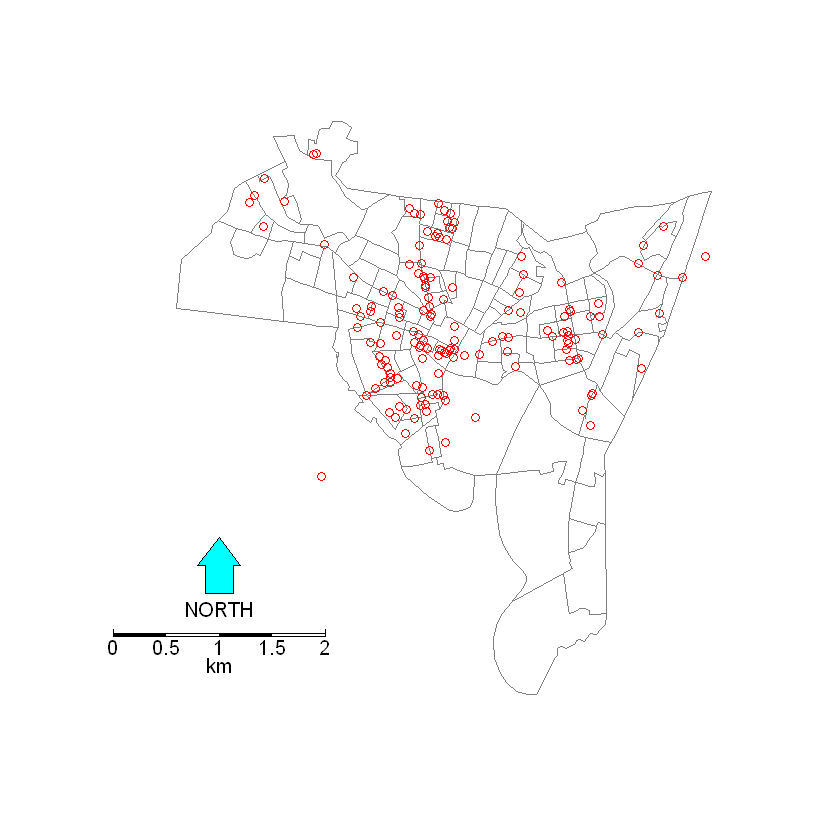

```r
plot(blocks, lwd = 0.5, border = "grey50")
plot(breach, col = "red", pch = 1, add = TRUE)
map.scale(534750, 152000, 15000, "km", 4, 0.5)
north.arrow(534750, 155000, 1000, col = "cyan")
```

This adds (overlays) the north arrow to the map. Again, the first two parameters are the location of the arrow. The thirds parameter specifies the size/length of the arrow and the `col` parameter specifies the colour that the arrow is filled with. if left unspecified, it will be filed in white. Remember that the `locator()` function introduced in Section 1 - this can be very useful for determining where to place items such as scale bars and north arrows in plot windows. A final decoration to the map is a map title. Suppose the map is to be called "New Haven, CT.". Then enter the code below to add the title to the map:

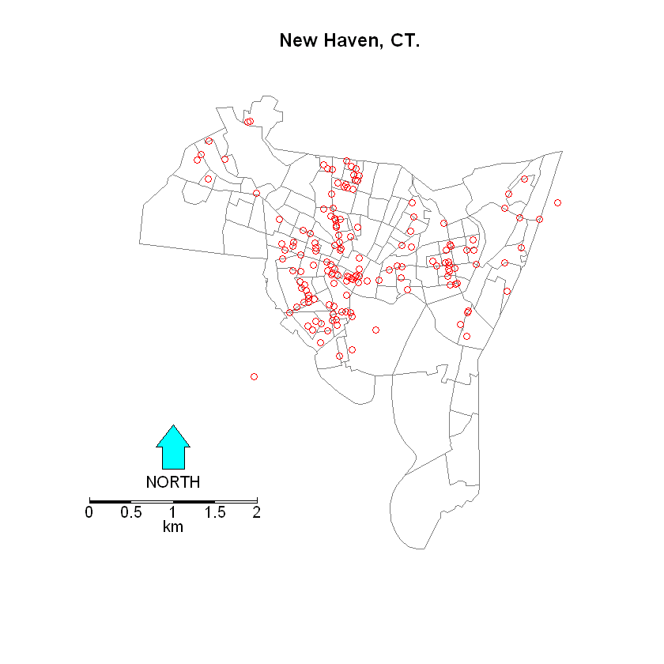

```r
plot(blocks, lwd = 0.5, border = "grey50")
plot(breach, col = "red", pch = 1, add = TRUE)
map.scale(534750, 152000, 15000, "km", 4, 0.5)
north.arrow(534750, 155000, 1000, col = "cyan")
title('New Haven, CT.')
```

This looks more like a decent map now would you not say?

### 2.2.4 Saving your map

Having created a map in a window on the screen, you may now want to save the map for either printing, or incorporating in a document. There are several ways that this can be accomplished. The simplest way is to right-click with the mouse on the map window, select **copy** or **copy image to clipboard** (Mac) or **Copy as metafile** or **Copy as bitmap** (Windows), and then paste it into a word-processing document (openOffice or MS Windows). Another way is to highlight the window and to use **File > Save as** to save the map as an image file, with a name that you give it. If you want to be fancy with it, you can also use the R commands to save the maps. I will you with this homework to figure out on your own.